# gganimate - Packages functionality examples using Gapminder data

I recently found an interesting R package that animates **ggplot2** plots, namely gganimate. This [notebook](http://rmarkdown.rstudio.com/r_notebooks.html) shows some functionalities of it, solely for learning purposes. As a test data set I use [gapminder](https://www.gapminder.org/data/) like in the examples of the gganimate package. Nevertheless, I am interested, whether it would support in me in these areas_

1. Data analysis, i.e., does it help to generate insights more efficiently?
2. Data visualization, i.e., does it help to better communicate findings?

This notebook is organized as follows: **Setup**, first I show necessary software and settings as well as give an data overview. In **Non-animated plots** I show some plots that I would create in order to assess the data without any animation for a later comparison. In section **Animated plots** I try **gganimate** to create animated plots. I conclude in the last section **Conclusion**.

Contact: [gresch](https://twitter.com/gre__sch)

# Setup

### Software

1. Install R
2. Install RStudio
3. Install [ImageMagick](https://www.imagemagick.org/script/binary-releases.php)
4. Install *gganimate* via `devtools::install_github("dgrtwo/gganimate")`

### Libraries

```r
library(gganimate)       # animation package
library(ggplot2)         # plotting package
library(gapminder)       # package with data to visualize
library(dplyr)           # package for data transformation
```

### Settings

```r
theme_set(theme_bw())    # set theme to black and white
```

### Data overview

The data is an *excerpt of the Gapminder data on life expectancy, GDP per capita, and population by country.* It includes 1704 observations with six variables:

- country
- continent
- year
- lifeExp
- pop
- gdpPerCap

```r
knitr::kable(summary(gapminder))
```

|  | country | continent | year | lifeExp | pop | gdpPercap |
| --- | --- | --- | --- | --- | --- | --- |
|  | Afghanistan: 12 | Africa :624 | Min. :1952 | Min. :23.60 | Min. :6.001e+04 | Min. : 241.2 |
|  | Albania : 12 | Americas:300 | 1st Qu.:1966 | 1st Qu.:48.20 | 1st Qu.:2.794e+06 | 1st Qu.: 1202.1 |
|  | Algeria : 12 | Asia :396 | Median :1980 | Median :60.71 | Median :7.024e+06 | Median : 3531.8 |
|  | Angola : 12 | Europe :360 | Mean :1980 | Mean :59.47 | Mean :2.960e+07 | Mean : 7215.3 |
|  | Argentina : 12 | Oceania : 24 | 3rd Qu.:1993 | 3rd Qu.:70.85 | 3rd Qu.:1.959e+07 | 3rd Qu.: 9325.5 |
|  | Australia : 12 | NA | Max. :2007 | Max. :82.60 | Max. :1.319e+09 | Max. :113523.1 |
|  | (Other) :1632 | NA | NA | NA | NA | NA |

```r
knitr::kable(head(gapminder, 15))
```

| country | continent | year | lifeExp | pop | gdpPercap |
| --- | --- | --- | --- | --- | --- |
| Afghanistan | Asia | 1952 | 28.801 | 8425333 | 779.4453 |
| Afghanistan | Asia | 1957 | 30.332 | 9240934 | 820.8530 |
| Afghanistan | Asia | 1962 | 31.997 | 10267083 | 853.1007 |
| Afghanistan | Asia | 1967 | 34.020 | 11537966 | 836.1971 |
| Afghanistan | Asia | 1972 | 36.088 | 13079460 | 739.9811 |
| Afghanistan | Asia | 1977 | 38.438 | 14880372 | 786.1134 |
| Afghanistan | Asia | 1982 | 39.854 | 12881816 | 978.0114 |
| Afghanistan | Asia | 1987 | 40.822 | 13867957 | 852.3959 |
| Afghanistan | Asia | 1992 | 41.674 | 16317921 | 649.3414 |
| Afghanistan | Asia | 1997 | 41.763 | 22227415 | 635.3414 |
| Afghanistan | Asia | 2002 | 42.129 | 25268405 | 726.7341 |
| Afghanistan | Asia | 2007 | 43.828 | 31889923 | 974.5803 |
| Albania | Europe | 1952 | 55.230 | 1282697 | 1601.0561 |
| Albania | Europe | 1957 | 59.280 | 1476505 | 1942.2842 |
| Albania | Europe | 1962 | 64.820 | 1728137 | 2312.8890 |

# Non-animated plots

Before testing **gganimate** I will create some plots via **ggplot**. For this analysis I will concentrate on the relationship between *GDP per capita* and *life expectancy at birth*. To increase readability, I log10ed the x-axis and used *color* to differentiate between observations coming from different *continents*. It shows a somewhat positive relationship between these two variables.

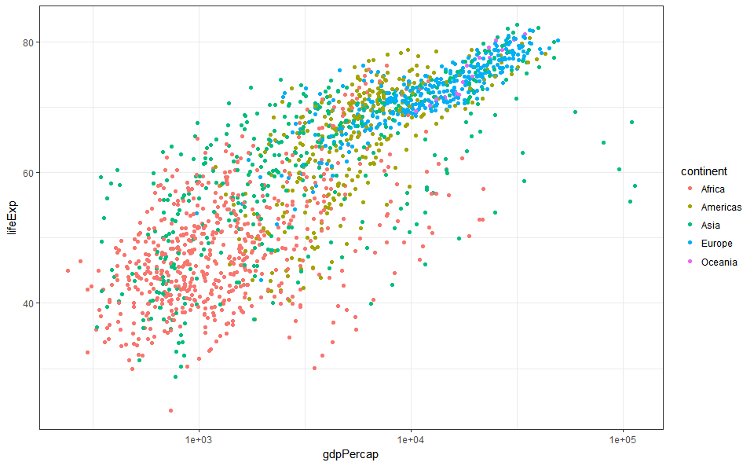

```r
ggplot(gapminder) +
  geom_point(aes(gdpPercap, lifeExp, color = continent)) +
  scale_x_log10()
```

What are *possible* ways to look at the *development* of these variables over time (e.g., years)? Here are some means:

1. Scatter plot: use of `facet_grid(~year)`
2. Area: Show averages and use `facet_grid(~year)`

### Scatterplot: use of `facet_grid(~year)`

It overall shows a positive development of *life expectancy* and *GDP per capita* over the years, with Europe leading and Africa tailing.

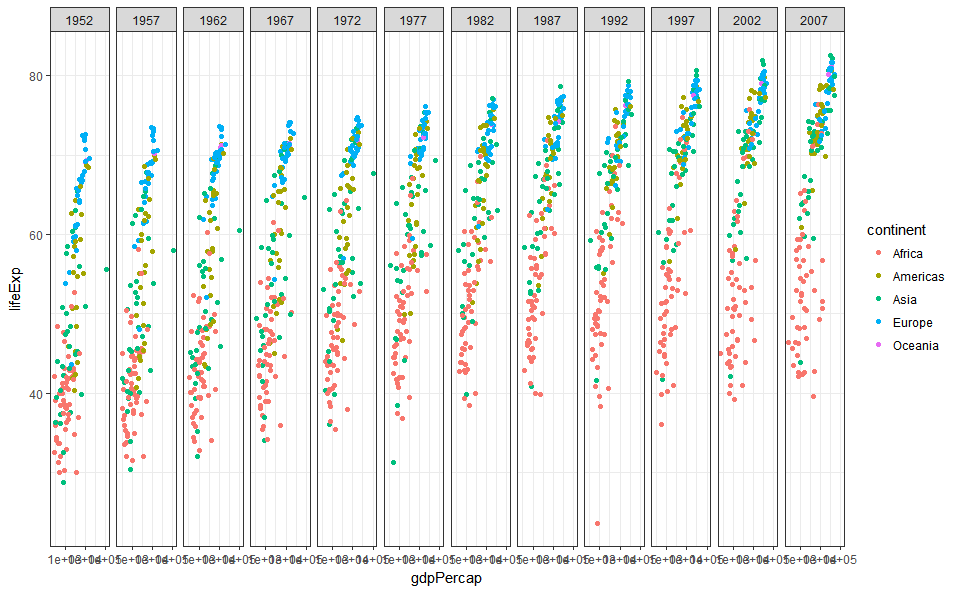

```r
ggplot(gapminder) +
  geom_point(aes(gdpPercap, lifeExp, color = continent)) +
  scale_x_log10() +
  facet_grid(~year)
```

### Area: Show averages and use `facet_grid(~year)`

This plot also shows a positive development of *life expectancy* and *GDP per capita* over the years, without showing differentiation for *continents*.

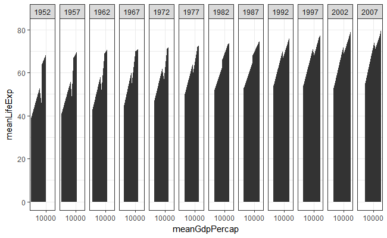

```r
gapminder %>%
  group_by(continent, year) %>%
  summarise(meanLifeExp = round(mean(lifeExp), 0),
            meanGdpPercap = round(mean(gdpPercap), 0)) %>%
  ggplot() +
  geom_area(aes(meanGdpPercap, meanLifeExp), stat = "identity") +
  scale_x_log10() +
  facet_grid(~year)
```

# Animated plots

The package **gganimate** gives me another possibility: to have initial plot for every year provided and to display them in a series. In this case the variable *year* needs to be set as the *frame*.

### Animated scatterplot

The animated scatter plot shows me the initial plot (i.e., two variables on the axes and the one variable as color fill). In addition, each frame shows a specific year. Frames change every second. Hence, it is possible to view developments over time.

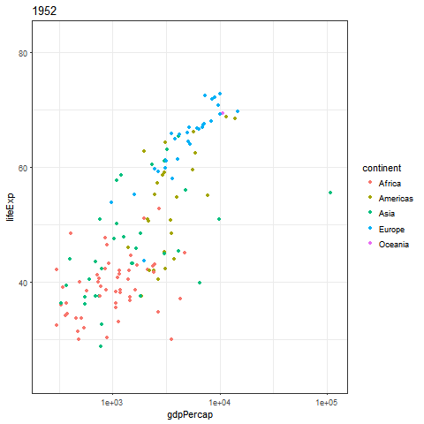

```r
gg_animate(ggplot(gapminder) +
            geom_point(aes(gdpPercap, lifeExp, color = continent, frame = year)) +
            scale_x_log10())
```

A `facet_grid(~continent)` further allows now a differentiation on the individual continent developments.

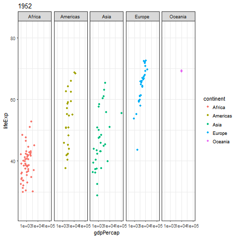

```r
gg_animate(ggplot(gapminder) +
            geom_point(aes(gdpPercap, lifeExp, color = continent, frame = year)) +
            scale_x_log10() +
             facet_grid(~continent))
```

### Line chart

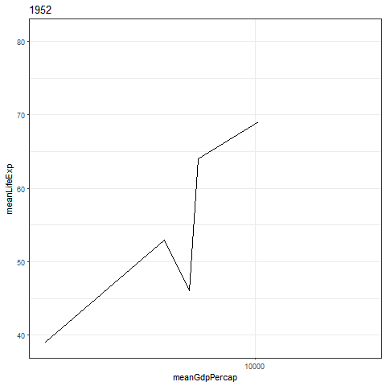

```r
gg_animate(gapminder %>%
  group_by(continent, year) %>%
  summarise(meanLifeExp = round(mean(lifeExp), 0),
            meanGdpPercap = round(mean(gdpPercap), 0)) %>%
  ggplot() +
  geom_line(aes(meanGdpPercap, meanLifeExp, frame = year), stat = "identity") +
  scale_x_log10())
```

# Conclusion

**gganimate** is an interesting package with some advantages. I will try to use it more often from now on. One open question would be whether it is possible to change *width* and *height* of the animated plots.

**1. Data analysis, i.e., does it help to generate insights more efficiently?**

In terms of data analysis it brings only few benefits. Other plots and means of exploration are available to understand the data, such as histograms, table view, or facet grids.

**2. Data visualiazation, i.e., does it help to better communicate findings?**

In terms of data visualization I believe **gganimate** is helpful. The *frame* provides another dimension to a plot without the need to use color, sizes, or other means that might clutter the plot. Another advantage is that I can tell a story and its *development* over time (or other variable). Lastly, I think adding animation to visualization is much more compelling and people might *engange* much more with the plot.